# Desafio 3: Combinação e Visualização de Dados

Entregar até 14h00 de 08/05/2020

Beatriz Milz

HTML compilado em: 08 de maio de 2020

```r
## Carregar pacotes
library(tidyverse) # pacote que inclui diversos pacotes para ciência de dados
library(dplyr)
library(readr)
```

## Roteiro

**1)** Vamos trabalher de novo com os dados eleitorais do Tribunal Superior Eleitoral. Vá ao Repositório de Dados Eleitorais do TSE. O TSE disponibiliza dados sobre os resultados eleitorais separadamente dos dados sobre os candidatos.

**R:** Recebido pelo professor por email.

**1) a)** Na aba de ‘resultados’, faça o download do arquivo “Votação nominal por município e zona” para 2016 e descompacte-o.

**R:** Recebido pelo professor por email.

**1) b)** Na aba de ‘candidatos’, faça o download do arquivo “Candidatos” para 2016 e descompacte-o.

**R:** Recebido pelo professor por email.

**1) c)** Dos arquivos descompactados, abre os dois bancos para Roraima (RR) em R com os parâmetros apropriados (note que o formato é um pouco diferente dos arquivos no desafio 1). Para detalhes sobre as colunas, veja o parte apropriado do documento leiame.pdf nos arquivos.

```r
consulta_cand_2016_RR <-
  read_delim(
    "dados/consulta_cand_2016_RR.csv",
    ";",
    escape_double = FALSE,
    locale = locale(encoding = "ISO-8859-1"),
    col_types = cols(SQ_CANDIDATO = col_character(), SQ_COLIGACAO = col_character()),
    trim_ws = TRUE
  )

# View(consulta_cand_2016_RR)
```

```r
votacao_candidato_munzona_2016_RR <-
  read_delim(
    "dados/votacao_candidato_munzona_2016_RR.csv",
    ";",
    escape_double = FALSE,
    col_types = cols(SQ_CANDIDATO = col_character(), SQ_COLIGACAO = col_character()),
    locale = locale(encoding = "ISO-8859-1"),
    trim_ws = TRUE
  )

# View(votacao_candidato_munzona_2016_RR)
```

**2)** Queremos analisar os resultados eleitorais baseado nas características dos candidatos, então precisamos juntar os dois bancos.

**2) a)** Identifique a unidade de análise do banco de candidatos - o que repesenta cada observação/linha? Quais variáveis identificam cada linha exclusivamente? (Cuidado: o número do candidato (NR_CANDIDATO) não é único para cada candidato).

**R:** Cada linha da base “consulta_cand_idato_2016_RR” representa um/uma candidato/a na eleição do ano de 2016, estado de Roraima. A variável que identifica cada linha exclusivamente é SQ_CANDIDATO.

```r
# consulta_cand_2016_RR$SQ_CANDIDATO %>% unique() %>% length()
```

**2) b)** Identifique a unidade de análise do banco de resultados - o que repesenta cada observação/linha? Quais variáveis identificam cada linha exclusivamente?

**R:** Cada linha da base “votacao_candidato_munzona_2016_RR” representa os cadidatos por zona na eleição do ano de 2016, estado de Roraima. As variáveis que identificam cada linha exclusivamente são SQ_CANDIDATO e NR_ZONA.

```r
# votacao_candidato_munzona_2016_RR %>% select(SQ_CANDIDATO, NR_ZONA) %>% unique() %>% nrow()
```

**2) c)** Liste as variáveis que compõem os identificadores comuns para realizar a junção dos dois bancos.

**R:** `SQ_CANDIDATO`

**2) d)** Use anti_join para identificador se há resultados que faltam detalhes do seu candidato no banco de dados de candidatos.

```r
# anti_join(votacao_candidato_munzona_2016_RR,
#           consulta_cand_2016_RR,
#           by = c("SQ_CANDIDATO"))

# Aqui está dando erro.. (?)
```

**2) e)** Use anti_join para identificador se há candidatos faltando no banco de dados de resultados. (Bonus: Investigando as colunas do resultado de anti_join, você pode identificar porque eles não existem no banco de resultados?).

```r
ex_2e <- anti_join(consulta_cand_2016_RR, votacao_candidato_munzona_2016_RR, by = "SQ_CANDIDATO")
```

**R:** Existem 201 candidatos faltando no banco de dados de resultados.

**2) f)** Não precisamos trabalhar com todas as colunas para a análise então para limpar os dados e deixar mais fácil entende-los, selecionar apenas as próximas colunas:

- Candidatos: SQ_CANDIDATO, NM_CANDIDATO, SG_PARTIDO, NR_IDADE_DATA_POSSE, DS_GENERO, DS_GRAU_INSTRUCAO, DS_COR_RACA
- Resultados: SQ_CANDIDATO, NM_MUNICIPIO, NR_ZONA, DS_CARGO, NR_TURNO, DS_CARGO, DS_SIT_TOT_TURNO, QT_VOTOS_NOMINAIS

```r
candidatos <-
  consulta_cand_2016_RR %>% select(
    SQ_CANDIDATO,
    NM_CANDIDATO,
    SG_PARTIDO,
    NR_IDADE_DATA_POSSE,
    DS_GENERO,
    DS_GRAU_INSTRUCAO,
    DS_COR_RACA
  )

resultados <-
  votacao_candidato_munzona_2016_RR %>% select(
    SQ_CANDIDATO,
    NM_CANDIDATO,
    NM_MUNICIPIO,
    NR_ZONA,
    DS_CARGO,
    NR_TURNO,
    DS_CARGO,
    DS_SIT_TOT_TURNO,
    QT_VOTOS_NOMINAIS
  )
```

**2)*** Por algum motivo, queremos calcular um resumo do total de votos recebidos por cada candidato em todas as eleições de 2016 - todas as zonas, todos os turnos, etc.

**2) a)** * Agregar o seu banco de resultados para ter uma linha por candidato resumindo o seu número de votos total.

```r
resultados_votos_totais <- resultados %>%
  group_by(SQ_CANDIDATO) %>%
  summarise(total_votos = sum(QT_VOTOS_NOMINAIS, na.rm = TRUE))
```

**2) b)*** Execute um join do tipo apropriado para criar uma tabela de todos os candidatos que se inscreveram para a eleição com os seus dados pessoais, incluindo o número de votos total calculado em (a).

```r
ex_2b <- left_join(candidatos, resultados_votos_totais, by = "SQ_CANDIDATO")

head(ex_2b)
```

| SQ_CANDIDATO | NM_CANDIDATO | SG_PARTIDO | NR_IDADE_DATA_POSSE | DS_GENERO | DS_GRAU_INSTRUCAO | DS_COR_RACA | total_votos |
| --- | --- | --- | --- | --- | --- | --- | --- |
| 230000001765 | ALDENOR DE LIMA | PDT | 44 | MASCULINO | ENSINO FUNDAMENTAL COMPLETO | PARDA | 125 |
| 230000001146 | JOAO BATISTA ARAUJO DA SILVA | PT | 35 | MASCULINO | SUPERIOR COMPLETO | PARDA | 6 |
| 230000001206 | PEDRO MAGALHAES DE SOUZA | SD | 51 | MASCULINO | ENSINO MÉDIO INCOMPLETO | PARDA | 54 |
| 230000002650 | MAX FERREIRA DOS SANTOS | PPS | 33 | MASCULINO | ENSINO MÉDIO COMPLETO | PARDA | 274 |
| 230000002105 | ITAMAR ELIAS DE OLIVEIRA JUNIOR | PSD | 35 | MASCULINO | ENSINO FUNDAMENTAL INCOMPLETO | PRETA | 249 |
| 230000002759 | JOSÉ ALTAIR COLARES OLIVEIRA | PP | 47 | MASCULINO | ENSINO FUNDAMENTAL COMPLETO | BRANCA | 129 |

**3)** Execute um join do tipo apropriado para uma análise comparando as caractéristicas dos candidatos que correram e os seus resultados eleitorais.

```r
dados_unidos <- left_join(resultados, candidatos, by = c("SQ_CANDIDATO", "NM_CANDIDATO"))
```

**4) a)** Filtre os seus dados juntados em Questão 3 para focar nas eleições para vereador.

```r
eleicoes_vereador <- dados_unidos %>% filter(DS_CARGO == "Vereador")
```

**4) b)** **[Omitida na versão inicial, exemplo de código fornecido]** Resume os dados dos vereadores para agregar os dados por município (somando os dados das zonas eleitorais em cada município).

```r
combinado_vereador <- eleicoes_vereador %>%
  group_by(
    SQ_CANDIDATO,
    NM_MUNICIPIO,
    DS_CARGO,
    NR_TURNO,
    DS_SIT_TOT_TURNO,
    NM_CANDIDATO,
    SG_PARTIDO,
    NR_IDADE_DATA_POSSE,
    DS_GENERO,
    DS_GRAU_INSTRUCAO,
    DS_COR_RACA
  ) %>%
  summarize(QT_VOTOS_NOMINAIS = sum(QT_VOTOS_NOMINAIS, na.rm = T)) %>%
  ungroup()
```

**5)** Para o nosso primeiro gráfico, vamos apresentar o número de candidatos para vereador por município, usando o banco de dados criado em questão 4.

**5) a)** Escolhe um tipo de gráfico apropriado e crie o gráfico.

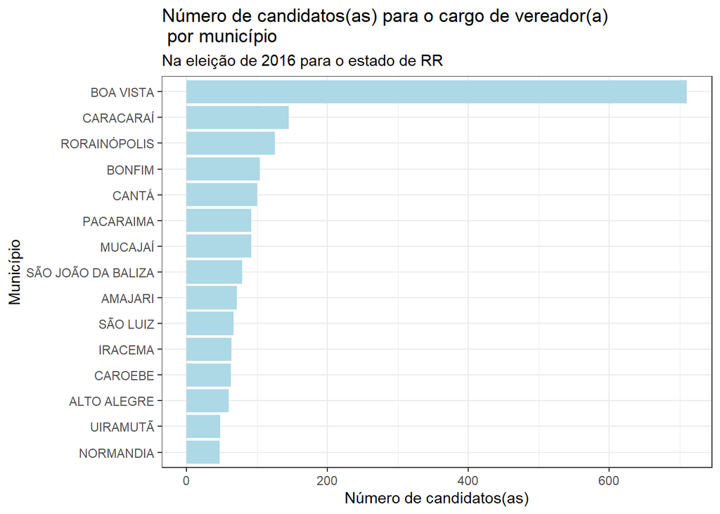

```r
eleicoes_vereador %>%
  group_by(NM_MUNICIPIO) %>%
  tally() %>%
  ggplot() +
  geom_col(aes(x = reorder(NM_MUNICIPIO , n), y = n), fill = "lightblue") +
  coord_flip() +
  theme_bw() +
  labs(
    title = "Número de candidatos(as) para o cargo de vereador(a) \n por município",
    subtitle = "Na eleição de 2016 para o estado de RR",
    x = "Município",
    y = "Número de candidatos(as)"
  )
```

**5) b)** Adicione um título ao seu gráfico, e rótulos nos eixos.

**R:** Feito no exercício anterior.

**5) c)** Use o código da camada + theme(axis.text.x = element_text(angle = 90)) para virar o texto do município para deixar mais visível.

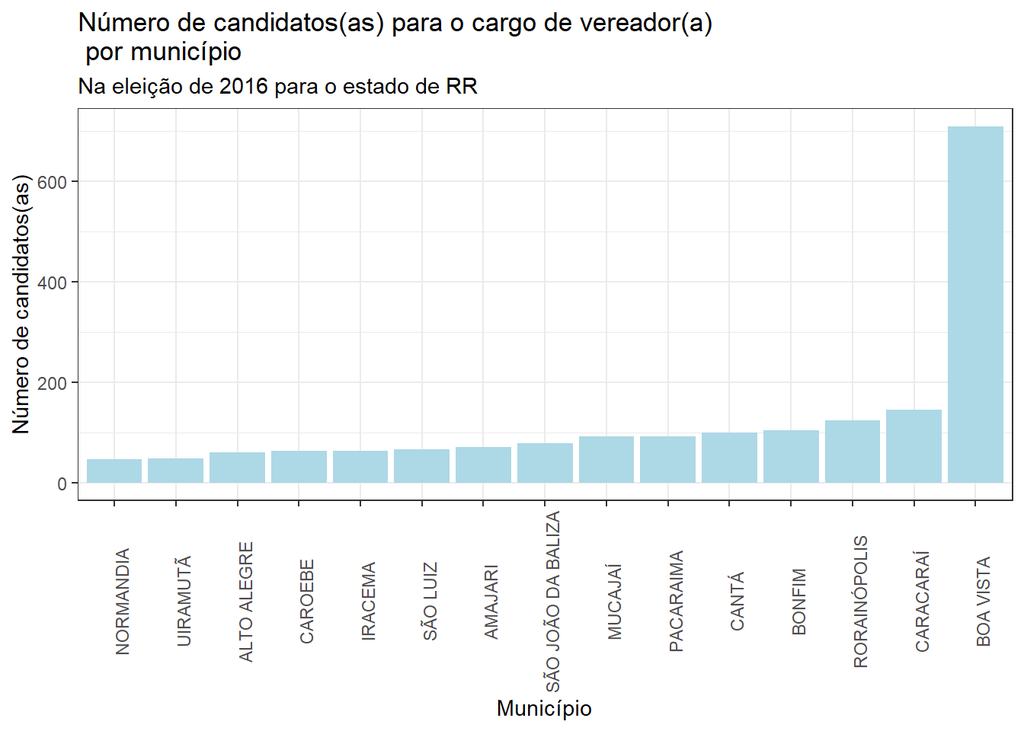

```r
eleicoes_vereador %>%
  group_by(NM_MUNICIPIO) %>%
  tally() %>%
  ggplot() +
  geom_col(aes(x = reorder(NM_MUNICIPIO , n), y = n), fill = "lightblue") +
  theme_bw() +
  labs(
    title = "Número de candidatos(as) para o cargo de vereador(a) \n por município",
    subtitle = "Na eleição de 2016 para o estado de RR",
    x = "Município",
    y = "Número de candidatos(as)"
  ) +
  theme(axis.text.x = element_text(angle = 90))
```

**6)** Agora, a nossa questão de pesquisa é o número de candidatos por gênero (variável DS_GENERO) no estado inteiro, usando o banco de dados de vereadores de questão 4. Prepare um gráfico apropriado, com título, rótulos nos eixos e aplique um tema simples da sua escolha.

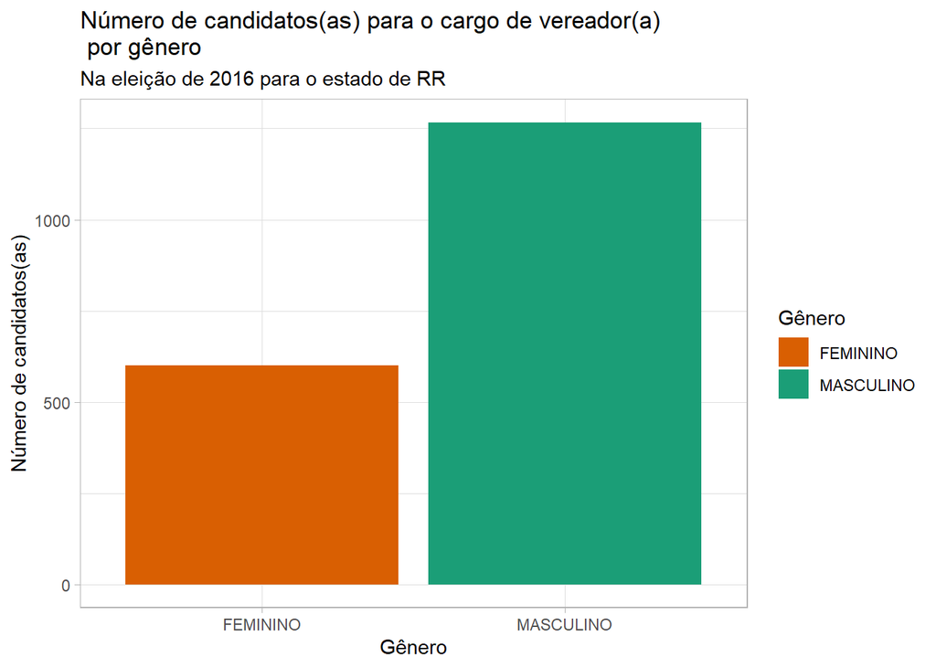

```r
eleicoes_vereador %>%
  group_by(DS_GENERO) %>% tally() %>%
  ggplot() +
  geom_col(aes(x = DS_GENERO, y = n, fill = DS_GENERO)) +
  scale_fill_brewer(palette = "Dark2", direction = -1) +
  theme_light() +
  labs(
    x = "Gênero",
    y = "Número de candidatos(as)",
    title = "Número de candidatos(as) para o cargo de vereador(a) \n por gênero",
    subtitle = "Na eleição de 2016 para o estado de RR",
    fill = "Gênero"
  )
```

**6) a)** Gere um gráfico apropriado que mostra o porcentagem de candidatos por gênero em cada município, usando o banco de dados de vereadores de questão 4.

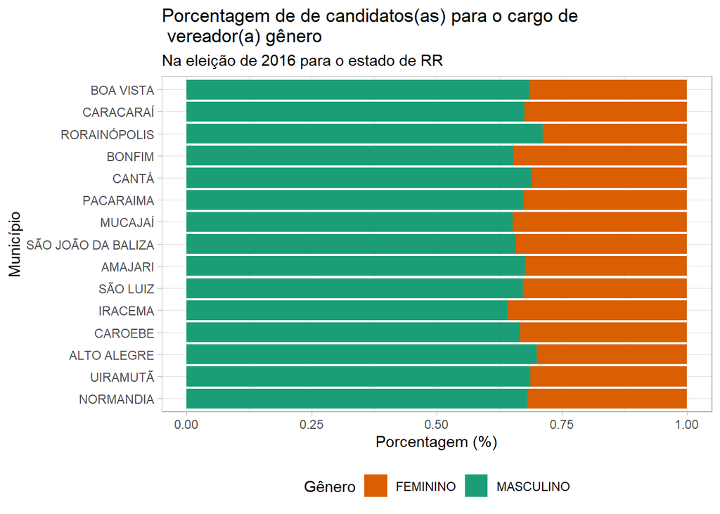

```r
eleicoes_vereador %>%
  group_by(NM_MUNICIPIO, DS_GENERO) %>% tally() %>%
  ggplot() +
  geom_col(aes(
    x = reorder(NM_MUNICIPIO , n),
    y = n,
    fill = DS_GENERO
  ), position = "fill") +
  scale_fill_brewer(palette = "Dark2", direction = -1) +
  coord_flip() +
  theme_light() +
  labs(
    x = "Município",
    y = "Porcentagem (%)",
    title = "Porcentagem de de candidatos(as) para o cargo de \n vereador(a) gênero",
    subtitle = "Na eleição de 2016 para o estado de RR",
    fill = "Gênero"
  ) +
  theme(legend.position = "bottom")
```

**6) b)** Formate o seu gráfico com títulos, rótulos nos eixos, virando o texto no eixo x, e ajuste a legenda para que ela fique abaixo do gráfico.

**R:** Feito no exercício anterior.

**7) a)** Gere uma variável binário para os vereadores eleitos (da variável DS_SIT_TOT_TURNO), e calcule a taxa de sucesso (% eleito) de candidatos por município e gênero.

```r
eleicoes_vereador <-
  eleicoes_vereador %>% mutate(
    binario_eleito = case_when(
      DS_SIT_TOT_TURNO == "ELEITO POR QP" ~ TRUE,
      DS_SIT_TOT_TURNO == "ELEITO POR MÉDIA" ~ TRUE,
      DS_SIT_TOT_TURNO == "NÃO ELEITO" ~ FALSE,
      DS_SIT_TOT_TURNO == "SUPLENTE" ~ FALSE

    )
  )

genero_porcentagem <-
  eleicoes_vereador %>% group_by(NM_MUNICIPIO, DS_GENERO) %>%
  summarise(
    total_eleito = sum(binario_eleito == TRUE),
    total_nao_eleito = sum(binario_eleito == FALSE)
  ) %>%
  mutate(
    total = total_eleito + total_nao_eleito,
    porcentagem_eleito = (total_eleito / total) * 100
  )
```

**7) b)** Mostre um gráfico de barras da taxa de sucesso (% eleito) dos candidatos femininos por município, com formatação apropriada.

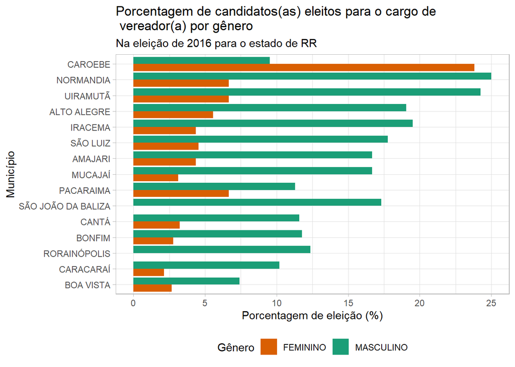

```r
genero_porcentagem  %>%
  ggplot() +
  geom_col(aes(
    x = reorder(NM_MUNICIPIO , porcentagem_eleito),
    y = porcentagem_eleito,
    fill = DS_GENERO
  ),
  position = "dodge") +
  coord_flip() +
  scale_fill_brewer(palette = "Dark2", direction = -1) +
  theme_light() +
  labs(
    x = "Município",
    y = "Porcentagem de eleição (%)",
    title = "Porcentagem de candidatos(as) eleitos para o cargo de \n vereador(a) por gênero",
    subtitle = "Na eleição de 2016 para o estado de RR",
    fill = "Gênero"
  ) +
  theme(legend.position = "bottom")
```

**7) c)** Extende o seu gráfico para mostrar a taxa de sucesso de homens e mulheres lado a lado, por município.

**R:** Feito no exercício anterior.

**7)** d) Qual é o município em que as mulheres têm uma maior taxa de sucesso que os homens?

**R:** Caroebe

**8)** Gere um gráfico de ‘tile’, que mostra o número de candidatos por município e gênero. Aplique uma escala de cores apropriado da sua escolha. Formate o seu gráfico.

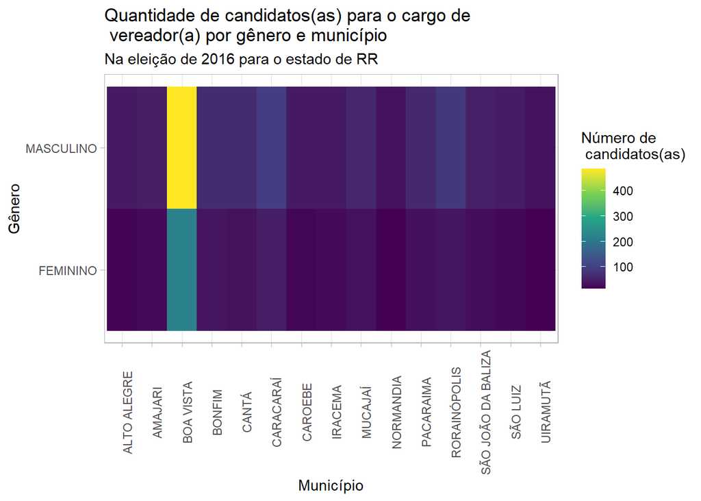

```r
eleicoes_vereador %>%
  group_by(NM_MUNICIPIO, DS_GENERO) %>% tally() %>%
  ggplot() +
  geom_tile(aes(x = NM_MUNICIPIO, y = DS_GENERO, fill = n)) +
  scale_fill_viridis_c() +
  theme_light() +
  theme(axis.text.x = element_text(angle = 90)) +
  labs(
    x = "Município",
    y = "Gênero",
    title = "Quantidade de candidatos(as) para o cargo de \n vereador(a) por gênero e município",
    subtitle = "Na eleição de 2016 para o estado de RR",
    fill = "Número de \n candidatos(as)"
  )
```

**9) a)** Apresente um gráfico de histograma da idade dos candidatos (NR_IDADE_DATA_POSSE). Faça qualquer ajuste necessário para que o seu gráfico faz sentido e incorpora valores de idade possíveis. Formate o seu gráfico.

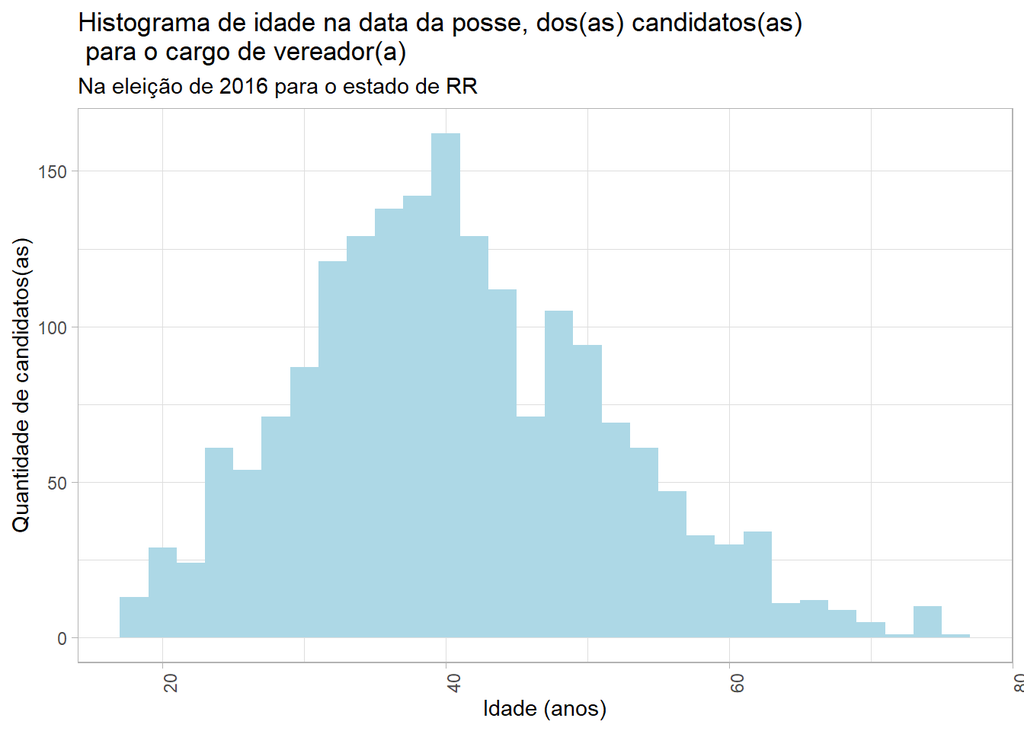

```r
# Essa base tem valores discrepantes criado por um erro! Filtrei para idade menor que 100 anos.
eleicoes_vereador %>%
  filter(NR_IDADE_DATA_POSSE < 100) %>%
  ggplot() +
  geom_histogram(aes(x = NR_IDADE_DATA_POSSE), fill = "lightblue")   +
  theme_light() +
  theme(axis.text.x = element_text(angle = 90)) +
  labs(
    x = "Idade (anos)",
    y = "Quantidade de candidatos(as)",
    title = "Histograma de idade na data da posse, dos(as) candidatos(as) \n para o cargo de vereador(a)",
    subtitle = "Na eleição de 2016 para o estado de RR"
  )
```

**9) b)** Apresente o mesmo gráfico de histograma da idade dos candidatos, mas agora separado por gênero.

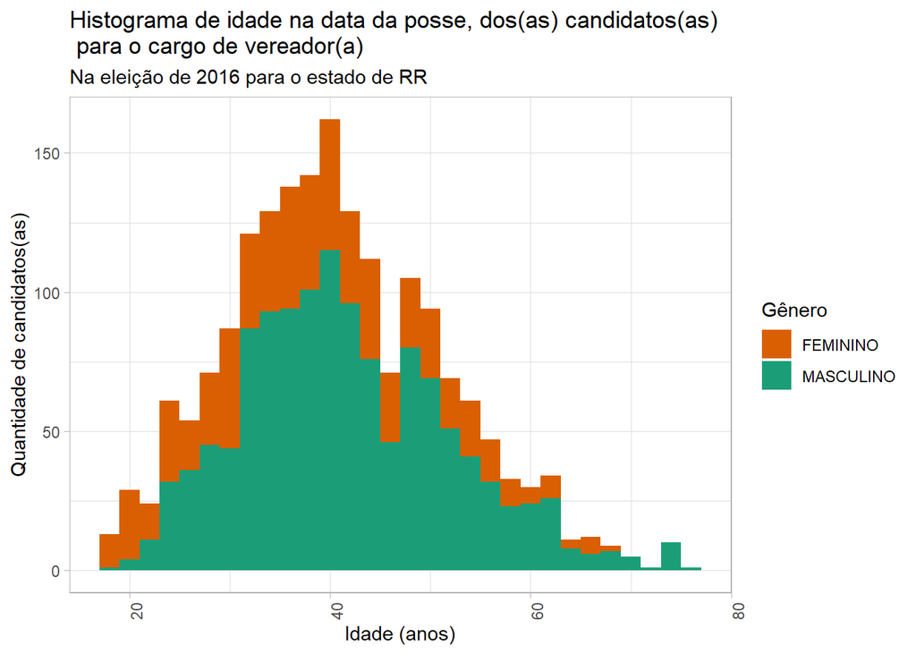

```r
# Essa base tem valores discrepantes criado por um erro! Filtrei para idade menor que 100 anos.
eleicoes_vereador %>%
  filter(NR_IDADE_DATA_POSSE < 100) %>%
  ggplot() +
  geom_histogram(aes(x = NR_IDADE_DATA_POSSE, fill = DS_GENERO))   +
  scale_fill_brewer(palette = "Dark2", direction = -1) +
  theme_light() +
  theme(axis.text.x = element_text(angle = 90)) +
  labs(
    x = "Idade (anos)",
    y = "Quantidade de candidatos(as)",
    title = "Histograma de idade na data da posse, dos(as) candidatos(as) \n para o cargo de vereador(a)",
    subtitle = "Na eleição de 2016 para o estado de RR",
    fill = "Gênero"
  )
```

**9) c)** Como uma forma alternativa de apresentar os dados, divide o seu gráfico de histograma em facets diferentes, dividido por gênero e raça.

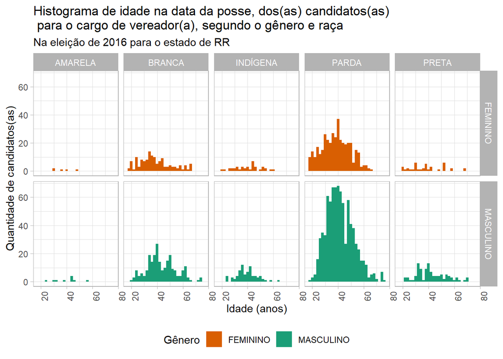

```r
# Essa base tem valores discrepantes criado por um erro! Filtrei para idade menor que 100 anos.
eleicoes_vereador %>%
  filter(NR_IDADE_DATA_POSSE < 100) %>%
  ggplot() +
  geom_histogram(aes(x = NR_IDADE_DATA_POSSE, fill = DS_GENERO))   +
  scale_fill_brewer(palette = "Dark2", direction = -1) +
  theme_light() +
  theme(axis.text.x = element_text(angle = 90)) +
  labs(
    x = "Idade (anos)",
    y = "Quantidade de candidatos(as)",
    title = "Histograma de idade na data da posse, dos(as) candidatos(as) \n para o cargo de vereador(a), segundo o gênero e raça",
    subtitle = "Na eleição de 2016 para o estado de RR",
    fill = "Gênero"
  ) +
  facet_grid(DS_GENERO ~ DS_COR_RACA) +
  theme(legend.position = "bottom")
```

**10) a)** Calcule o porcentagem de votos dos candidatos no seu município.

```r
eleicoes_vereador_porcentagem <-
  eleicoes_vereador %>%
  group_by(SQ_CANDIDATO, NM_CANDIDATO, NM_MUNICIPIO) %>%
  summarise(total_votos_candidato = sum(QT_VOTOS_NOMINAIS, na.rm = TRUE)) %>%
  ungroup() %>%
  group_by(NM_MUNICIPIO) %>%
  mutate(
    total_votos_municipio = sum(total_votos_candidato, na.rm = TRUE),
    porcentagem_votos_munic = round((
      total_votos_candidato /
        total_votos_municipio
    ) * 100, 2)
  ) %>%
  select(-total_votos_candidato, -total_votos_municipio)

head(eleicoes_vereador_porcentagem)
```

| SQ_CANDIDATO | NM_CANDIDATO | NM_MUNICIPIO | porcentagem_votos_munic |
| --- | --- | --- | --- |
| 230000000826 | ADRIANO AMADEU DANTAS BEZERRA | CARACARAÍ | 0.30 |
| 230000000827 | AMAURI RODRIGUES RAMOS | CARACARAÍ | 0.13 |
| 230000000828 | ANTONIO GOMES DE SOUZA | CARACARAÍ | 0.70 |
| 230000000829 | ARNOLDO FERREIRA LIMA | CARACARAÍ | 0.28 |
| 230000000830 | EDSON DE JESUS | CARACARAÍ | 0.87 |
| 230000000831 | HEBERSON JUSTINO VALERIO | CARACARAÍ | 0.47 |

```r
# Checando se totaliza 100% para cada municipio
# eleicoes_vereador_porcentagem %>% group_by(NM_MUNICIPIO) %>% summarise(total_porc = sum(porcentagem_votos_munic, na.rm = TRUE))
```

**10) b)** Calcule a média do porcentagem de votos dos candidatos por idade.

```r
eleicoes_vereador_porc_idade <-
  eleicoes_vereador %>% left_join(
    eleicoes_vereador_porcentagem,
    by = c("SQ_CANDIDATO", "NM_CANDIDATO", "NM_MUNICIPIO")
  ) %>%
  filter(NR_IDADE_DATA_POSSE < 100) %>%
  group_by(NR_IDADE_DATA_POSSE) %>%
  summarise(media_porcentagem_idade = round(mean(porcentagem_votos_munic, na.rm = TRUE), 2))

head(eleicoes_vereador_porc_idade)
```

| NR_IDADE_DATA_POSSE | media_porcentagem_idade |
| --- | --- |
| 18 | 0.12 |
| 19 | 0.02 |
| 20 | 0.48 |
| 21 | 0.08 |
| 22 | 0.60 |
| 23 | 1.62 |

**10) c)** Mostre num gráfico de linhas o porcentagem média de votos dos candidatos (no eixo y) por idade do candidato (no eixo x). Formate o seu gráfico.

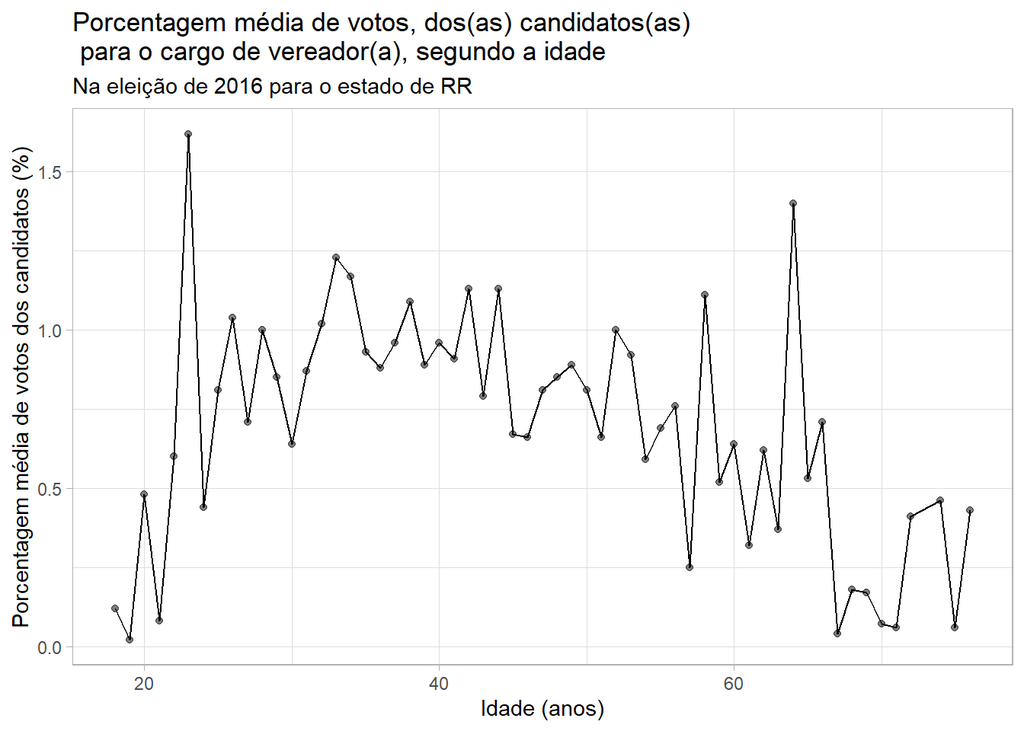

```r
eleicoes_vereador_porc_idade %>%
  ggplot() +
  geom_line(aes(x =  NR_IDADE_DATA_POSSE, y = media_porcentagem_idade)) +
  geom_point(aes(x =  NR_IDADE_DATA_POSSE, y = media_porcentagem_idade),
             alpha = 0.5) +
  theme_light() +
  labs(
    x = "Idade (anos)",
    y = "Porcentagem média de votos dos candidatos (%)",
    title = "Porcentagem média de votos, dos(as) candidatos(as) \n para o cargo de vereador(a), segundo a idade",
    subtitle = "Na eleição de 2016 para o estado de RR"
  ) +
  theme(legend.position = "bottom")
```

**10) d)** Mostre num gráfico da linhas o porcentagem de votos dos candidatos (no eixo y) por idade do candidato (no eixo x), com linhas separadas por gênero.

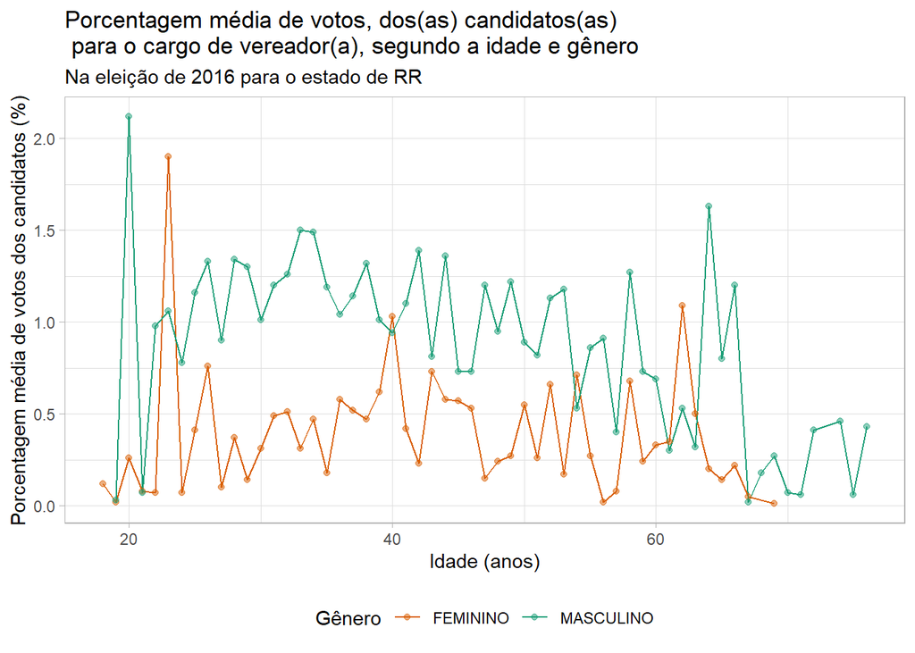

```r
eleicoes_vereador_porc_idade_genero <-
  eleicoes_vereador %>% left_join(
    eleicoes_vereador_porcentagem,
    by = c("SQ_CANDIDATO", "NM_CANDIDATO", "NM_MUNICIPIO")
  ) %>%
  filter(NR_IDADE_DATA_POSSE < 100) %>%
  group_by(NR_IDADE_DATA_POSSE, DS_GENERO) %>%
  summarise(media_porcentagem_idade = round(mean(porcentagem_votos_munic, na.rm = TRUE), 2))


eleicoes_vereador_porc_idade_genero %>%
  ggplot() +
  geom_line(aes(x =  NR_IDADE_DATA_POSSE, y = media_porcentagem_idade, colour = DS_GENERO)) +
  geom_point(aes(x =  NR_IDADE_DATA_POSSE, y = media_porcentagem_idade, colour = DS_GENERO),
             alpha = 0.5) +
  scale_color_brewer(palette = "Dark2", direction = -1) +
  theme_light() +
  labs(
    x = "Idade (anos)",
    y = "Porcentagem média de votos dos candidatos (%)",
    title = "Porcentagem média de votos, dos(as) candidatos(as) \n para o cargo de vereador(a), segundo a idade e gênero",
    subtitle = "Na eleição de 2016 para o estado de RR",
    colour = "Gênero"
  ) +
  theme(legend.position = "bottom")
```

**10) e)** Em qual idade os homens e as mulheres tem a maior chance para ganhar a eleição?

```r
ex10e <-
  eleicoes_vereador %>% filter(binario_eleito == TRUE) %>% group_by(DS_GENERO, NR_IDADE_DATA_POSSE) %>% tally() %>% arrange(-n)


masc_10e <-
  ex10e  %>% filter(DS_GENERO == "MASCULINO") %>% .[[1, 2]]


fem_10e <-
  ex10e  %>% filter(DS_GENERO == "FEMININO")  %>% .[[1, 2]]
```

**R:** Considerando os dados das eleições para o cargo de vereador(a) de RR para o ano de 2016, dentre as pessoas que ganharam a eleição, a idade mais frequente para pessoas do gênero masculino é 38 anos, e para as pessoas do gênero feminino é 43 anos.

**11) a)** Calcule o voto total de cada partido (não candidato) em cada município nas eleições para vereador em 2016. Depois, calcular o porcentagem do voto de cada partido em cada município.

```r
votos_partido <- eleicoes_vereador %>%
  group_by(NM_MUNICIPIO, SG_PARTIDO) %>%
  summarise(total_votos_partido = sum(QT_VOTOS_NOMINAIS, na.rm = TRUE)) %>%
  ungroup() %>%
  group_by(NM_MUNICIPIO) %>%
  mutate(
    total_votos_municipio = sum(total_votos_partido, na.rm = TRUE),
    porcentagem_votos_partido_munic = round(100 * (
      total_votos_partido / total_votos_municipio
    ), 2)
  )
```

**11) b)** Use o código abaixo para gerar uma tabela de IDH (Indíce de Desenvolvimento Humano em 2010) por município.

```r
IDH <-
  tibble(
    NM_MUNICIPIO = c(
      "ALTO ALEGRE",
      "AMAJARI",
      "BOAVISTA",
      "BONFIM",
      "CANTÁ",
      "CARACARAÍ",
      "CAROEBE",
      "IRACEMA",
      "MUCAJAÍ",
      "NORMANDIA",
      "PACARAIMA",
      "RORAINOPOLIS",
      "SÃO JOÃO DA BALIZA",
      "SÃO LUIZ",
      "UIRAMUTÃ"
    ),
    IDH = c(
      0.542,
      0.484,
      0.752,
      0.626,
      0.619,
      0.624,
      0.639,
      0.582,
      0.665,
      0.594,
      0.650,
      0.619,
      0.655,
      0.649,
      0.453
    )
  )
```

**11) c)** Juntar os dados de voto por partido de questão (a) com a tabela de HDI de questão (b). Verifique que o join deu certo para todas as observações, identifique o motivo pelos erros, e corrija os erros.

```r
IDH_corrigido <- IDH %>% mutate(
  NM_MUNICIPIO = case_when(
    NM_MUNICIPIO == "BOAVISTA" ~ "BOA VISTA",
    NM_MUNICIPIO == "RORAINOPOLIS" ~ "RORAINÓPOLIS",
    TRUE ~ NM_MUNICIPIO
  )
)


idh_municipio_partido <-
  left_join(votos_partido, IDH_corrigido, by = c("NM_MUNICIPIO")) %>% arrange(IDH)
```

**11) d)** Crie um gráfico de pontos do IDH do município no eixo X por porcentagem de votos do partido PMDB no eixo Y. Adicione um título e rótulos nos eixos.

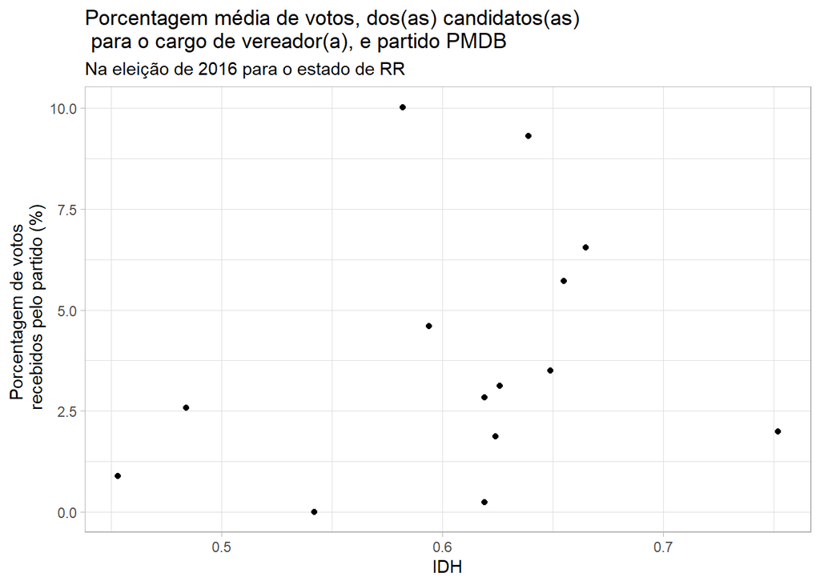

```r
idh_municipio_partido %>%
  filter(SG_PARTIDO == "PMDB") %>%
  ggplot() +
  geom_point(aes(y = porcentagem_votos_partido_munic, x = IDH)) +
  theme_light() +
  labs(
    x = "IDH",
    y = "Porcentagem de votos \n recebidos pelo partido (%)",
    title = "Porcentagem média de votos, dos(as) candidatos(as) \n para o cargo de vereador(a), e partido PMDB",
    subtitle = "Na eleição de 2016 para o estado de RR"
  )
```

**11) e)** Ajuste o seu gráfico na questão (d) para que o tamanho do ponto mostra o total de votos que o PMDB recebeu no munícipio.

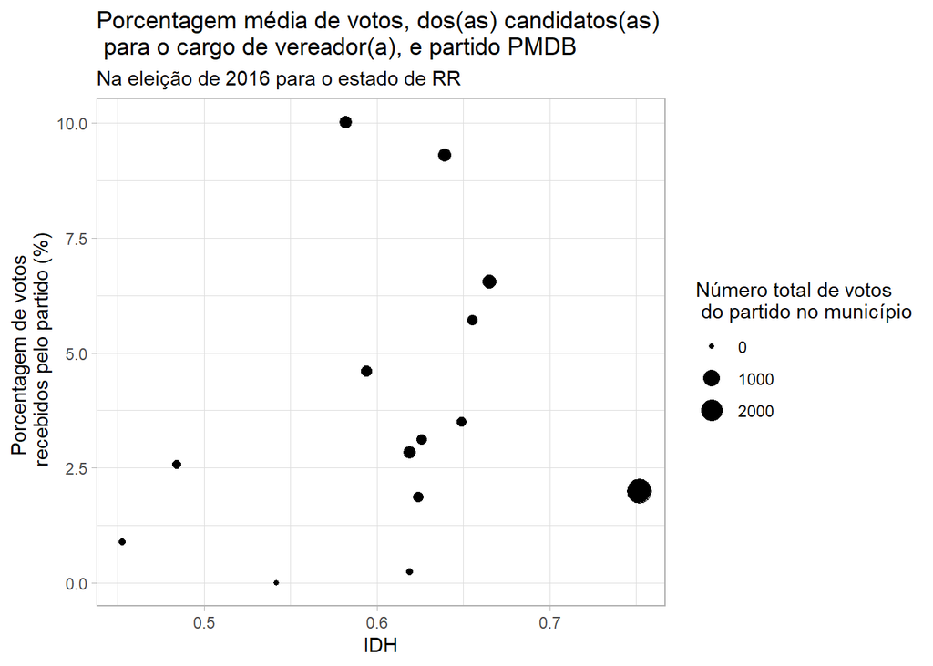

```r
idh_municipio_partido %>%
  filter(SG_PARTIDO == "PMDB") %>%
  ggplot() +
  geom_point(aes(y = porcentagem_votos_partido_munic, x = IDH, size = total_votos_partido)) +
  theme_light() +
  labs(
    x = "IDH",
    y = "Porcentagem de votos \n recebidos pelo partido (%)",
    title = "Porcentagem média de votos, dos(as) candidatos(as) \n para o cargo de vereador(a), e partido PMDB",
    subtitle = "Na eleição de 2016 para o estado de RR",
    size = "Número total de votos \n do partido no município"
  )
```

**11) f)** Ajuste o seu gráfico na questão (d) para que o cor dos pontos (em vez do tamanho) mostra o total de votos que o PMDB recebeu no munícipio. Aplique uma escala de cores apropriado da sua escolha.

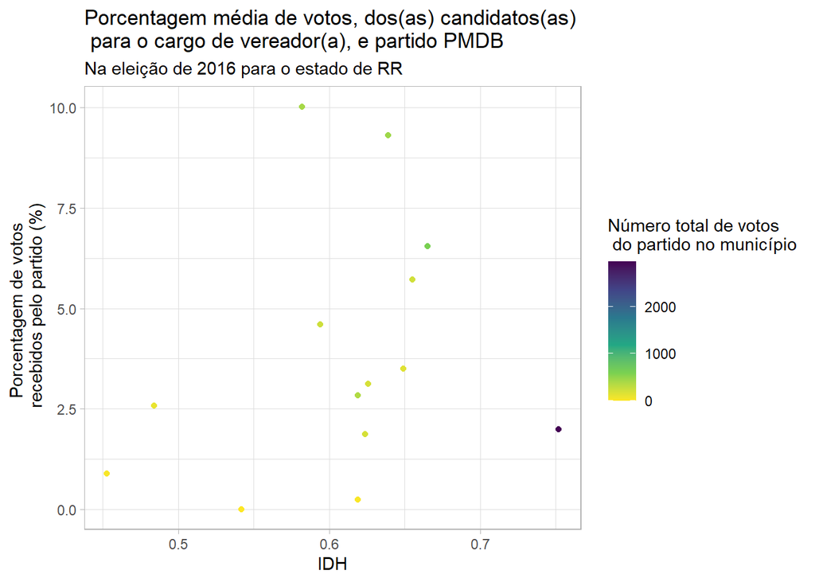

```r
idh_municipio_partido %>%
  filter(SG_PARTIDO == "PMDB") %>%
  ggplot() +
  geom_point(aes(y = porcentagem_votos_partido_munic, x = IDH, color = total_votos_partido)) +
  scale_color_viridis_c(direction = -1) +
  theme_light() +
  labs(
    x = "IDH",
    y = "Porcentagem de votos \n recebidos pelo partido (%)",
    title = "Porcentagem média de votos, dos(as) candidatos(as) \n para o cargo de vereador(a), e partido PMDB",
    subtitle = "Na eleição de 2016 para o estado de RR",
    color = "Número total de votos \n do partido no município"
  )
```